# Modelo de Aiyagari - Mercados Incompletos (SS e Welfare)

## Cálculo do Steady State

```python
##############################################################
# Importação de módulos/pacotes
##############################################################
import numpy as np
import matplotlib.pyplot as plt

##############################################################
# Definição de parâmetros e objetos
##############################################################
beta, sigma = .95, 10
delta, alpha = .04, .3

barA, a_max, n_a = 0, 50, 100
# barA, a_max, n_a = 0, 20, 20
a_grid = np.linspace( -barA, a_max, n_a )

pi = np.array([ [2/3, 1/3],
                [1/3, 2/3]])

y_min, y_max, n_y = 1, 5, len(pi)
y_grid = np.linspace( y_min, y_max, n_y )

rho = 1/beta - 1
# r_min, r_max, n_r = -delta, rho, 20
# r_grid = np.linspace( r_min, r_max, n_r )

##############################################################
# Definição de funções
##############################################################
def U(x):
    # return (x**(1-sigma) - 1) / (1-sigma)
    return (x**(1-sigma) ) / (1-sigma)  # AJUSTOU AQUI P/ ADEQUAR CRRA ÀS PASSAGENS DO EFEITO EQUIVALENTE
# U = lambda x: (x**(1-sigma) - 1) / (1-sigma)
```

**Computação do Equilíbrio Geral**. Considere o seguinte algoritmo:

1. Fixe um $r \in (-\delta, \rho)$. Para um $r$ fixo, podemos resolver o problema recursivo do domicílio (e.g. pela iteração da função valor ou da função política). Isso resulta numa função valor $v_r$ e regras de decisão $a'_r, c_r$, que dependem do $r$ fixado.
   - Relembre que: $$ \beta = \frac{1}{1+\rho} \iff \rho = \frac{1-\beta}{\beta} $$
   - Usando $L = \bar{L}\ $ (distribuição da oferta agregada de trabalho)
   - $r \overset{(7.24)}{\longrightarrow} K(r) \overset{(7.25)}{\longrightarrow} w(r) \longrightarrow$ Problema Recursivo do Domicílio
2. A função política $a'_r$ e $\pi$ induzem uma função de transição de Markov $Q_r$. Compute a única medida estacionária $\Phi_r$ associada com essa função de transição de (7.29).
3. Compute o excesso de demanda por capital $$ d(r) = K(r) - \mathbb{E}a(r) \tag{7.47} $$
4. Note que $d(r)$ é apenas um número:
   - Se esse número é igual a zero, então encontramos o RCE estacionário
   - Se não for, atualizamos o guess para $r$ e começamos do passo 1 novamente:
     - Se $\mathbb{E}a(r)$ for crescente em $r$ (o efeito de substituição se sobrepõe ao efeito de renda e aos efeitos de renda indiretos potenciais das mudanças em salários), então $d(r)$ é uma função estritamente decrescente.
   - A atualização deve ser tal que
     - se $d(r) > 0$, aumente o guess para o $r$,
     - se $d(r) < 0$, diminua o guess para o $r$.

```python
############################################################
## Construção da oferta agregada de trabalho barL
############################################################
barL = 0

## Construção da distribuição estacionária de PI
## (distribuição dos indivíduos nos y's)
# definindo guess inicial
PI_bar = np.ones(n_y)
PI_bar = PI_bar / np.sum(PI_bar)

norm_PI, tol_PI = 1, 1e-4
while norm_PI > tol_PI:
    PI_prime = np.dot(np.transpose(pi), PI_bar)
    norm_PI = np.max(abs(PI_prime - PI_bar))
    PI_bar = PI_prime[:]  # ou np.copy(PI_prime)

# Acumulando valor em barL
for i_y, y in enumerate(y_grid):
    barL += y * PI_bar[i_y]

############################################################
## Construção da função objetivo
############################################################
V = np.zeros((n_y, n_a))
d_path, K_path, Ea_path, r_path = [], [], [], []

r_L, r_H = -delta, rho
norm_r, tol_r = 3, 1e-4

while norm_r > tol_r:
    """ ===================== PASSO 1 ===================== """
    r = (r_L + r_H )/2

    ############################################################
    ## Construção da demanda de capital K_r (usando 7.24)
    ############################################################
    # F(K,L) = K^\alpha * L^(1-\alpha)
    # F_k(K,L) =\alpha K^(\alpha-1) * L^(1-\alpha)
    #
    # r = F_k(K,L) - delta        [7.24]
    # r + delta = F_k(K_r, barL) = \alpha K_r^(\alpha-1) * barL^(1-\alpha)
    # K_r^(1-\alpha) = \alpha * barL^(1-\alpha) / (r + delta)
    # K_r = (\alpha * barL^(1-\alpha) / (r + delta)) ^ (\frac{1}{(1-\alpha)})
    aux = alpha * barL**(1 - alpha) / (r + delta)
    K_r = aux ** (1 / (1 - alpha))


    ############################################################
    ## Cálculo do salário w (usando 7.25)
    ############################################################
    # F(K, L) = K^\alpha * L^(1-alpha)
    # F_L(K, L) = (1-\alpha) K^\alpha * L^(-\alpha)
    #
    # w = F_L(K,L)       [7.25]
    # w = F_L(K_r, barL) = (1 - \alpha) K_r^\alpha * barL^(-\alpha)
    # w = (1 - \alpha) (K_r / barL)^\alpha
    w = (1 - alpha) * (K_r / barL)**alpha


    ## Construindo a função objetivo
    norm_V, tol_V = 2, 1e-5
    while norm_V > tol_V:
        F_OBJ = np.zeros((n_y, n_a, n_a))
        for i_a in range(n_a):
            a = a_grid[i_a]

            for i_y in range(n_y):
                y = y_grid[i_y]

                for i_aa in range(n_a):
                    aa = a_grid[i_aa]

                    c = w * y + (1+r)*a - aa

                    if c <= 0:
                        F_OBJ[i_y, i_a, i_aa] = -np.inf
                    else:
                        F_OBJ[i_y, i_a, i_aa] = U(c) + beta * np.dot(pi[i_y,:], V[:, i_aa])


        ######################################################
        ## Construção da função valor (Operador de Bellman)
        ######################################################
        TV = np.zeros((n_y, n_a))
        iG = np.zeros((n_y, n_a), dtype=np.int64)

        for i_a, a in enumerate(a_grid):
        # for i_a in range(n_a):
        #     a = a_grid[i_a]

            for i_y, y in enumerate(y_grid):
            # for i_y in range(n_y):
            #     y = a_grid[i_y]

                TV[i_y, i_a] = np.max(F_OBJ[i_y, i_a, :])
                iG[i_y, i_a] = np.argmax(F_OBJ[i_y, i_a, :])

        norm_V = np.max(abs(TV - V))
        # print(norm_V)
        V = TV[:]  # Ou V = np.copy(TV)


    """ ===================== PASSO 2 ===================== """
    ############################################################
    ## Construção da função de transição Q (induzida por a' e pi)
    ############################################################
    # Empilhando as variáveis de estado (dimensão única n_y x n_a)
    ### Estado atual (current state):
    # [(y_0, a_0), (y_0, a_1), (y_0, a_2), (y_0, a_3), (y_0, a_4),
    #  (y_1, a_0), (y_1, a_1), (y_1, a_2), (y_1, a_3), (y_1, a_4)]

    Q = np.zeros((n_y*n_a, n_y*n_a))
    # Só acumulo se passar pelo if (começa ZERADA)

    # Fixando o 'current state'
    for i_a, a in enumerate(a_grid):
        for i_y, y in enumerate(y_grid):
            c_state = i_a + (n_a * i_y)  # índice no grid empilhado
                # a varia de 1 em 1, y varia em 5 (n_a)
                # independe da ordem do loop

            # Fixando o 'next state'
            for i_aa, aa in enumerate(a_grid):
                for i_yy, yy in enumerate(y_grid):
                    n_state = i_aa + (n_a * i_yy)

                    # Verificando se há migração para aa
                    if iG[i_y, i_a] == i_aa:
                        # Q[(a, y), (a', y')]: current state -> new state
                        Q[c_state, n_state] += pi[i_y, i_yy]
                    # else:
                    #     Q[c_state, n_state] += 0

    # Q_(m x n)
    # Operador linear definido por de Q * v mapeia R^n em R^m
    # Pega valor de amanhã (coluna) e traz o valor de hoje (linha)
    # Por isso, precisa transpor abaixo (hoje -> amanhã)


    ############################################################
    ## Construção da distribuição estacionária phi_bar (usando 7.29)
    ############################################################
    # \phi(A, Y) = \int{ Q[ (a, y), (A, Y) ] d\phi}       [7.29]
    phi_bar = np.ones(n_y * n_a)  # 1 dimensão!
    phi_bar = phi_bar / sum(phi_bar)  # Normalizando a 1 (distr. uniforme)

    norm_phi, tol_phi = 1, 1e-4
    while norm_phi > tol_phi:
        phi_prime = np.dot(np.transpose(Q), phi_bar)
        norm_phi = np.max(abs(phi_prime - phi_bar))
        phi_bar = phi_prime[:]


    """ ===================== PASSO 3 ===================== """
    ############################################################
    ## Construção da oferta de capital Ea_r
    ############################################################
    Ea_r = 0
    for i_a, a in enumerate(a_grid):
        for i_y, y in enumerate(y_grid):
            c_state = i_a + (n_a * i_y)
            i_aa = iG[i_y, i_a]
            aa = a_grid[i_aa]
            Ea_r += aa * phi_bar[c_state]

    ############################################################
    ## Construção do excesso de demanda do capital
    ############################################################
    d_r = K_r - Ea_r
    d_path.append(d_r)
    K_path.append(K_r)
    Ea_path.append(Ea_r)
    r_path.append(r)


    """ ===================== PASSO 4 ===================== """
    ############################################################
    ## Atualização com resultados desta iteração
    ############################################################
    norm_r = abs(r_H - r_L)

    if d_r > 0:
        r_L = r
    else:
        r_H = r

print('Taxa de juros de SS:', r)
```

```
Taxa de juros de SS: 0.01061266447368418
```

```python
##############################################################
# Armazenando os valores de equilíbrio
##############################################################
phi_0 = phi_bar[:]
V_0 = V[:]
iG_0 = iG[:]
r_0, w_0, K_0 = r, w, K_r
```

### Cálculo do Steady State com Reforma Tributária

$\tau: 0 \rightarrow .1$

```python
##############################################################

print('Estudando a economia após a reforma tributária')

tau = .10

d_path, K_path, Ea_path = [], [], []

r_L, r_H = -delta, rho
norm_r, tol_r = 3, 1e-4
while norm_r > tol_r:
    r = (r_L + r_H )/2
    ##############################################################
    # Construção da demanda de capital
    ##############################################################
    # F(K,L) = K^\alpha * L^(1-\alpha)
    # F_k(K,L) =\alpha K^(\alpha-1) * L^(1-\alpha)
    # r + delta = F_k(K_r, barL) = \alpha K_r^(\alpha-1) * barL^(1-\alpha)
    # K_r^(1-\alpha) =  \alpha  * barL^(1-\alpha) / (r + delta)
    # K_r = ( \alpha  * barL^(1-\alpha) / (r + delta) ) ^ ( \frac{1}{(1-\alpha)} )
    aux = alpha  * (barL**(1-alpha)) / (r + delta)
    K_r = aux ** ( 1/(1-alpha) )


    # F(K,L) = K^\alpha * L^(1-\alpha)
    # F_L(K,L) =(1-\alpha) K^\alpha * L^(-\alpha)
    # w = F_L(K_r, barL) = (1-\alpha) K^\alpha * L^(-\alpha)
    w = (1-alpha) * (K_r / barL) ** alpha

    T = tau * r * K_r


    norm_V, tol_V = 2, 1e-5
    while norm_V>tol_V:
        ##############################################################
        # Construção da função objetivo
        ##############################################################
        F_OBJ = np.zeros( (n_y, n_a, n_a) )
        for i_a in range(n_a):
            a = a_grid[i_a]
            for i_y in range(n_y):
                y = y_grid[i_y]
                for i_aa in range(n_a):
                    aa = a_grid[i_aa]

                    c = w * y + (1+(1-tau)*r) * a - aa + T
                    if c<=0:
                        F_OBJ[i_y, i_a, i_aa] = - np.inf
                    else:
                        F_OBJ[i_y, i_a, i_aa] = U(c) + beta * np.dot( pi[i_y, :] , V[:, i_aa] )


        ##############################################################
        # Construção da função valor (operador Bellman)
        ##############################################################
        TV = np.zeros( (n_y, n_a) )
        iG = np.zeros( (n_y, n_a), dtype=np.int64 )

        for i_a, a in enumerate(a_grid):
        # for i_a in range(n_a):
        #     a = a_grid[i_a]
            for i_y, y in enumerate(y_grid):
            # for i_y in range(n_y):
            #     y = y_grid[i_y]
                TV[i_y, i_a] = np.max( F_OBJ[i_y, i_a, :] )
                iG[i_y, i_a] = np.argmax( F_OBJ[i_y, i_a, :] )

        norm_V = np.max(abs(TV-V))
        # print(norm_V)
        V = np.copy(TV)


    ##############################################################
    # Construção da função de transição
    ##############################################################

    # Empilhando as variáveis de estado
    # [ (y_0, a_0), (y_0, a_1), (y_0, a_2), (y_0, a_3), (y_0, a_4),
    #   (y_1, a_0), (y_1, a_1), (y_1, a_2), (y_1, a_3), (y_1, a_4)]
    # [ (y'_0, a'_0), (y'_0, a'_1), (y'_0, a'_2), (y'_0, a'_3), (y'_0, a'_4),
    #   (y'_1, a'_0), (y'_1, a'_1), (y'_1, a'_2), (y'_1, a'_3), (y'_1, a'_4)]
    Q = np.zeros( ( n_y*n_a , n_y*n_a ) )
    # Fixando o 'current state'
    for i_a, a in enumerate(a_grid):
        for i_y, y in enumerate(y_grid):
            c_state = i_a + n_a * i_y
            # Fixando o 'next state'
            for i_aa, aa in enumerate(a_grid):
                for i_yy, yy in enumerate(y_grid):
                    n_state = i_aa + n_a * i_yy
                    # Verificando se há migração para aa
                    if iG[i_y, i_a] == i_aa:
                        # Q ( (a,y), (a', y') )
                        Q[c_state, n_state] += pi[i_y, i_yy]
                    else:
                        Q[c_state, n_state] += 0

    # Q _(mxn)
    # operador linear definido por Q * v mapeia R^n em R^m

    ##############################################################
    # Construção da distribuição estacionária
    ##############################################################
    # definindo guess inicial para phi_bar
    phi_bar = np.ones( n_y*n_a )
    phi_bar = phi_bar / sum(phi_bar)
    # phi_bar /= sum(phi_bar)

    norm_phi, tol_phi = 1, 1e-4
    while norm_phi>tol_phi:
        # phi_prime = np.transpose(Q) * phi_bar
        phi_prime = np.dot( np.transpose(Q) , phi_bar )
        norm_phi = np.max(abs(phi_prime - phi_bar))
        phi_bar = np.copy(phi_prime)




    ##############################################################
    # Construção da oferta de capital
    ##############################################################
    Ea_r = 0
    for i_a, a in enumerate(a_grid):
        for i_y, y in enumerate(y_grid):
            c_state = i_a + n_a * i_y
            i_aa = iG[i_y, i_a]
            aa = a_grid[i_aa]
            Ea_r += aa * phi_bar[c_state]

    ##############################################################
    # Construção do excesso de demanda do capital
    ##############################################################
    d_r = K_r - Ea_r
    d_path.append(d_r)
    K_path.append(K_r)
    Ea_path.append(Ea_r)

    norm_r = abs(r_H-r_L)

    if d_r > 0:
        r_L = r
    else:
        r_H = r
print('taxa de juros de SS:',r)

##############################################################
# Armazenando os valores de equilíbrio
##############################################################
phi_inf = phi_bar[:]
V_inf = V[:]
iG_inf = iG[:]
r_inf, w_inf, K_inf = r, w, K_r
```

```
Estudando a economia após a reforma tributária
taxa de juros de SS: 0.011064967105263127
```

### Estudando os Efeitos da Reforma (Welfare)

##### Variação na Utilidade/Função Valor

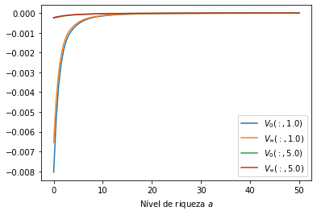

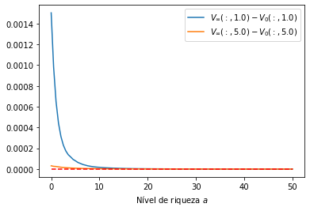

```python
##############################################################
# Estudando os efeitos da reforma
##############################################################
for i_y, y in enumerate(y_grid):
    plt.plot(a_grid, V_0[i_y,:],label=f'$V_0(:,{y})$')
    plt.plot(a_grid, V_inf[i_y,:],label=f'$V_\infty(:,{y})$')
plt.xlabel('Nível de riqueza $a$')
plt.legend()
plt.show()

for i_y, y in enumerate(y_grid):
    plt.plot(a_grid, V_inf[i_y,:] - V_0[i_y,:],label=f'$V_\infty(:,{y}) - V_0(:,{y})$')
plt.plot(a_grid, [0]*n_a,'r--')
plt.xlabel('Nível de riqueza $a$')
plt.legend()
plt.show()
```

- Está errado falar que pessoa que tem menos renda obteve maior utilidade do que o indivíduo com renda mais alta (não podemos comparar valores de utilidade entre pessoas distintas)
- Podemos comparar variação de utilidade em um mesmo indivíduo para verificar se cresceu.

##### Variação Equivalente

*Note abaixo que o professor não incluiu o $\frac{-1}{1-\sigma}$ nas preferências CRRA das passagens abaixo, então teve que ajustar na função `U(c)`.

Seja, no estado estacionário final, $$ v_\infty(a,y) = \mathbb{E}_0\left\{ \sum^\infty_{t=0}{\beta^t \frac{(\hat{c}_t)^{1-\sigma}}{1 - \sigma}} \right\} $$

Então, no estado estacionário inicial, $$ v_0(a,y) = \mathbb{E}_0\left\{ \sum^\infty_{t=0}{\beta^t \frac{(c^*_t)^{1-\sigma}}{1 - \sigma}} \right\} $$

em que $c^*$ (consumo o SS inicial) pode ser reescrito como uma proporção de $\hat{c}$ (consumo final), multiplicando por $(1+g)$: \begin{align} v_0(a,y; g) &= \mathbb{E}_0\left\{ \sum^\infty_{t=0}{\beta^t \frac{[(1+g)c^*_t]^{1-\sigma}}{1 - \sigma}} \right\} \\ &= \mathbb{E}_0\left\{ (1+g)^{1-\sigma} \sum^\infty_{t=0}{\beta^t \frac{(c^*_t)^{1-\sigma}}{1 - \sigma}} \right\} \tag{$\sigma$ não depende do tempo e formato da CRRA} \\ &= (1+g)^{1-\sigma} \mathbb{E}_0\left\{ \sum^\infty_{t=0}{\beta^t \frac{(c^*_t)^{1-\sigma}}{1 - \sigma}} \right\} \tag{operador $\mathbb{E_0}$ é linear} \\ &= (1+g)^{1-\sigma}. v_0(a,y) \end{align}

##### Qual é o percentual $g \in \mathbb{R}$ que torna o indivíduo $(a, y)$ indiferente entre o SS inicial com o aumento de consumo e o SS final (com $\tau$ elevado)?

\begin{align} v_0(a,y; g) &= v_\infty(a,y) \\ (1+g)^{1-\sigma}. v_0(a,y) &= v_\infty(a,y) \\ g(a, y) &= \left[ \frac{v_\infty(a,y)}{v_0(a,y)} \right]^{\frac{1}{1-\sigma}} - 1 \end{align}

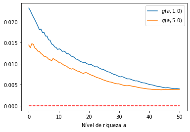

```python
g = np.zeros( (n_y, n_a) )
for i_y, y in enumerate(y_grid):
    for i_a, a in enumerate(a_grid):
        aux = V_inf[i_y, i_a] / V_0[i_y, i_a]
        g[i_y, i_a] = aux ** (1 / (1-sigma) ) - 1

for i_y, y in enumerate(y_grid):
    plt.plot(a_grid, g[i_y,:],label=f'$g(a,{y})$')
plt.plot(a_grid, [0]*n_a,'r--')
plt.xlabel('Nível de riqueza $a$')
plt.legend()
plt.show()
```